# Exploratory data analysis on COVID-19 pandemic

The coronavirus pandemic is an ongoing pandemic of coronavirus disease 2019 (COVID-19), caused by severe acute respiratory syndrome coronavirus 2 (SARS-CoV-2). The outbreak started in Wuhan, China, as early as November 2019. The World Health Organization declared the outbreak to be a public health emergency of international concern on 30th January 2020 and recognized it as a pandemic on 11th March 2020.

The pandemic has led to one of the biggest economical, political and social crisis mankind has faced in decades. Effective measures were slow to be put in practice due to the unknown and uncertainty related to the virus. Information has been of all different sorts, with many incorrect and false news being spread.

The purpose of this notebook is to have an understanding of the virus through data. By any means this analysis should not be taken into consideration for scientific purposes as there is a large number of variables that need to be considered for this (quarantines, quality of the medical resources deployed, environmental measures, etc).

**TABLE OF CONTENTS**

1. First look at the datasets
   1. Merging the data
   2. Editing features
2. EDA
   1. Worldwide cases
      1. Total and daily cases
      2. Confirmed, recovered and fatalities on a daily basis
      3. Growth Factor
      4. Active cases by date
      5. Top countries for total confirmed cases
      6. New cases for countries with most cases
      7. Active cases by country
      8. Outcome of cases
   2. China
      1. Total and daily cases
      2. Growth Factor
      3. Active cases
      4. Outcome of cases
   3. Europe
      1. Total and daily cases
      2. Growth Factor
      3. Active cases
      4. Outcome of cases
   4. USA
      1. Total and daily cases
      2. Growth Factor
      3. Active cases
      4. Outcome of cases
3. Disclaimer

## 1. First look at the datasets

We will be initially using the following datasets throughout the analysis:

- [COVID19 confirmed global](https://github.com/CSSEGISandData/COVID-19/blob/master/csse_covid_19_data/csse_covid_19_time_series/time_series_covid19_confirmed_global.csv)
- [COVID19 deaths global](https://github.com/CSSEGISandData/COVID-19/blob/master/csse_covid_19_data/csse_covid_19_time_series/time_series_covid19_deaths_global.csv)
- [COVID19 recovered global](https://github.com/CSSEGISandData/COVID-19/blob/master/csse_covid_19_data/csse_covid_19_time_series/time_series_covid19_recovered_global.csv)

These are from Johns Hopkins University's repo on github and have kindly been provided to the public for educational and academic research purposes. We will be importing first all the libraries used for this study and start loading the data.

```python
import itertools
from datetime import date
from datetime import timedelta
import numpy as np
import pandas as pd
import matplotlib.dates as mdates
import matplotlib.pyplot as plt
import seaborn as sns
%matplotlib inline
_ = sns.set()
```

```python
confirmed_df = pd.read_csv('https://raw.githubusercontent.com/CSSEGISandData/COVID-19/master/csse_covid_19_data/csse_covid_19_time_series/time_series_covid19_confirmed_global.csv')
confirmed_df.head()
```

|  | Province/State | Country/Region | Lat | Long | 1/22/20 | 1/23/20 | 1/24/20 | 1/25/20 | 1/26/20 | 1/27/20 | 1/28/20 | 1/29/20 | 1/30/20 | 1/31/20 | 2/1/20 | 2/2/20 | 2/3/20 | 2/4/20 | 2/5/20 | 2/6/20 | 2/7/20 | 2/8/20 | 2/9/20 | 2/10/20 | 2/11/20 | 2/12/20 | 2/13/20 | 2/14/20 | 2/15/20 | … |
| --- | --- | --- | --- | --- | --- | --- | --- | --- | --- | --- | --- | --- | --- | --- | --- | --- | --- | --- | --- | --- | --- | --- | --- | --- | --- | --- | --- | --- | --- | --- |
| 0 | NaN | Afghanistan | 33.0000 | 65.0000 | 0 | 0 | 0 | 0 | 0 | 0 | 0 | 0 | 0 | 0 | 0 | 0 | 0 | 0 | 0 | 0 | 0 | 0 | 0 | 0 | 0 | 0 | 0 | 0 | 0 | … |
| 1 | NaN | Albania | 41.1533 | 20.1683 | 0 | 0 | 0 | 0 | 0 | 0 | 0 | 0 | 0 | 0 | 0 | 0 | 0 | 0 | 0 | 0 | 0 | 0 | 0 | 0 | 0 | 0 | 0 | 0 | 0 | … |
| 2 | NaN | Algeria | 28.0339 | 1.6596 | 0 | 0 | 0 | 0 | 0 | 0 | 0 | 0 | 0 | 0 | 0 | 0 | 0 | 0 | 0 | 0 | 0 | 0 | 0 | 0 | 0 | 0 | 0 | 0 | 0 | … |
| 3 | NaN | Andorra | 42.5063 | 1.5218 | 0 | 0 | 0 | 0 | 0 | 0 | 0 | 0 | 0 | 0 | 0 | 0 | 0 | 0 | 0 | 0 | 0 | 0 | 0 | 0 | 0 | 0 | 0 | 0 | 0 | … |
| 4 | NaN | Angola | -11.2027 | 17.8739 | 0 | 0 | 0 | 0 | 0 | 0 | 0 | 0 | 0 | 0 | 0 | 0 | 0 | 0 | 0 | 0 | 0 | 0 | 0 | 0 | 0 | 0 | 0 | 0 | 0 | … |

5 rows × 90 columns

```python
fatalities_df = pd.read_csv('https://raw.githubusercontent.com/CSSEGISandData/COVID-19/master/csse_covid_19_data/csse_covid_19_time_series/time_series_covid19_deaths_global.csv')
fatalities_df.head()
```

|  | Province/State | Country/Region | Lat | Long | 1/22/20 | 1/23/20 | 1/24/20 | 1/25/20 | 1/26/20 | 1/27/20 | 1/28/20 | 1/29/20 | 1/30/20 | 1/31/20 | 2/1/20 | 2/2/20 | 2/3/20 | 2/4/20 | 2/5/20 | 2/6/20 | 2/7/20 | 2/8/20 | 2/9/20 | 2/10/20 | 2/11/20 | 2/12/20 | 2/13/20 | 2/14/20 | 2/15/20 | … |
| --- | --- | --- | --- | --- | --- | --- | --- | --- | --- | --- | --- | --- | --- | --- | --- | --- | --- | --- | --- | --- | --- | --- | --- | --- | --- | --- | --- | --- | --- | --- |
| 0 | NaN | Afghanistan | 33.0000 | 65.0000 | 0 | 0 | 0 | 0 | 0 | 0 | 0 | 0 | 0 | 0 | 0 | 0 | 0 | 0 | 0 | 0 | 0 | 0 | 0 | 0 | 0 | 0 | 0 | 0 | 0 | … |
| 1 | NaN | Albania | 41.1533 | 20.1683 | 0 | 0 | 0 | 0 | 0 | 0 | 0 | 0 | 0 | 0 | 0 | 0 | 0 | 0 | 0 | 0 | 0 | 0 | 0 | 0 | 0 | 0 | 0 | 0 | 0 | … |
| 2 | NaN | Algeria | 28.0339 | 1.6596 | 0 | 0 | 0 | 0 | 0 | 0 | 0 | 0 | 0 | 0 | 0 | 0 | 0 | 0 | 0 | 0 | 0 | 0 | 0 | 0 | 0 | 0 | 0 | 0 | 0 | … |
| 3 | NaN | Andorra | 42.5063 | 1.5218 | 0 | 0 | 0 | 0 | 0 | 0 | 0 | 0 | 0 | 0 | 0 | 0 | 0 | 0 | 0 | 0 | 0 | 0 | 0 | 0 | 0 | 0 | 0 | 0 | 0 | … |
| 4 | NaN | Angola | -11.2027 | 17.8739 | 0 | 0 | 0 | 0 | 0 | 0 | 0 | 0 | 0 | 0 | 0 | 0 | 0 | 0 | 0 | 0 | 0 | 0 | 0 | 0 | 0 | 0 | 0 | 0 | 0 | … |

5 rows × 90 columns

```python
recovered_df = pd.read_csv('https://raw.githubusercontent.com/CSSEGISandData/COVID-19/master/csse_covid_19_data/csse_covid_19_time_series/time_series_covid19_recovered_global.csv')
recovered_df.head()
```

|  | Province/State | Country/Region | Lat | Long | 1/22/20 | 1/23/20 | 1/24/20 | 1/25/20 | 1/26/20 | 1/27/20 | 1/28/20 | 1/29/20 | 1/30/20 | 1/31/20 | 2/1/20 | 2/2/20 | 2/3/20 | 2/4/20 | 2/5/20 | 2/6/20 | 2/7/20 | 2/8/20 | 2/9/20 | 2/10/20 | 2/11/20 | 2/12/20 | 2/13/20 | 2/14/20 | 2/15/20 | … |
| --- | --- | --- | --- | --- | --- | --- | --- | --- | --- | --- | --- | --- | --- | --- | --- | --- | --- | --- | --- | --- | --- | --- | --- | --- | --- | --- | --- | --- | --- | --- |
| 0 | NaN | Afghanistan | 33.0000 | 65.0000 | 0 | 0 | 0 | 0 | 0 | 0 | 0 | 0 | 0 | 0 | 0 | 0 | 0 | 0 | 0 | 0 | 0 | 0 | 0 | 0 | 0 | 0 | 0 | 0 | 0 | … |
| 1 | NaN | Albania | 41.1533 | 20.1683 | 0 | 0 | 0 | 0 | 0 | 0 | 0 | 0 | 0 | 0 | 0 | 0 | 0 | 0 | 0 | 0 | 0 | 0 | 0 | 0 | 0 | 0 | 0 | 0 | 0 | … |
| 2 | NaN | Algeria | 28.0339 | 1.6596 | 0 | 0 | 0 | 0 | 0 | 0 | 0 | 0 | 0 | 0 | 0 | 0 | 0 | 0 | 0 | 0 | 0 | 0 | 0 | 0 | 0 | 0 | 0 | 0 | 0 | … |
| 3 | NaN | Andorra | 42.5063 | 1.5218 | 0 | 0 | 0 | 0 | 0 | 0 | 0 | 0 | 0 | 0 | 0 | 0 | 0 | 0 | 0 | 0 | 0 | 0 | 0 | 0 | 0 | 0 | 0 | 0 | 0 | … |
| 4 | NaN | Angola | -11.2027 | 17.8739 | 0 | 0 | 0 | 0 | 0 | 0 | 0 | 0 | 0 | 0 | 0 | 0 | 0 | 0 | 0 | 0 | 0 | 0 | 0 | 0 | 0 | 0 | 0 | 0 | 0 | … |

5 rows × 90 columns

The datasets contain daily information on total number of confirmed cases, fatalities and recovered respectively. Some countries also have a region informed.

### 1. 1. Merging the data

The structure of the data is not bestly suited for an analysis. Let's create a function to change that.

```python
def reshape_data(df):
    to_keep = ["Country/Region", "Province/State", "Lat", "Long"]
    to_change = set(df.columns) - set(to_keep)
    df = pd.melt(df,
                 id_vars=to_keep,
                 value_vars=to_change,
                 var_name='date',
                 value_name='total')
    return df
```

The function `reshape_data()` melts the `DataFrame` in order to remove the dates from the columns. We can apply it to the three `DataFrame`s and then merge them together.

```python
def merge_dfs(df1, df2, df3):
    merged = pd.merge(reshape_data(df1), reshape_data(df2), how='inner', on=['Country/Region', 'Province/State', 'Lat', 'Long', 'date'])
    merged = pd.merge(merged, reshape_data(df3), how='inner', on=['Country/Region', 'Province/State', 'Lat', 'Long', 'date'])

    merged.columns = ['country', 'province', 'lat', 'long', 'date', 'confirmed', 'fatalities', 'recovered']
    merged['date'] = pd.to_datetime(merged['date'])
    merged = merged.sort_values(['country', 'province', 'date'])

    return merged

merged = merge_dfs(confirmed_df, fatalities_df, recovered_df)
merged.head(3)
```

|  | country | province | lat | long | date | confirmed | fatalities | recovered |
| --- | --- | --- | --- | --- | --- | --- | --- | --- |
| 12792 | Afghanistan | NaN | 33.0 | 65.0 | 2020-01-22 | 0 | 0 | 0 |
| 15498 | Afghanistan | NaN | 33.0 | 65.0 | 2020-01-23 | 0 | 0 | 0 |
| 19188 | Afghanistan | NaN | 33.0 | 65.0 | 2020-01-24 | 0 | 0 | 0 |

Great! Before moving on to some descriptive statistics we will also apply a few extra changes.

### 1. 2. Editing features

```python
print("Countries with Province/State informed: ", merged[merged['province'].isna()==False]['country'].unique())
```

```
Countries with Province/State informed:  ['Australia' 'China' 'Denmark' 'France' 'Netherlands' 'United Kingdom']
```

We can see that the region is stated for 6 countries only, we will be removing the column for now.

It will be taken into consideration if we will be analysing those countries separately.

```python
def drop_province(df):
    df = merged.groupby(['country', 'date']).agg({'lat': 'first',
                                                  'long': 'first',
                                                  'confirmed': 'sum',
                                                  'fatalities': 'sum',
                                                  'recovered': 'sum'}).reset_index()
    return df

df = drop_province(merged)
df.head()
```

|  | country | date | lat | long | confirmed | fatalities | recovered |
| --- | --- | --- | --- | --- | --- | --- | --- |
| 0 | Afghanistan | 2020-01-22 | 33.0 | 65.0 | 0 | 0 | 0 |
| 1 | Afghanistan | 2020-01-23 | 33.0 | 65.0 | 0 | 0 | 0 |
| 2 | Afghanistan | 2020-01-24 | 33.0 | 65.0 | 0 | 0 | 0 |
| 3 | Afghanistan | 2020-01-25 | 33.0 | 65.0 | 0 | 0 | 0 |
| 4 | Afghanistan | 2020-01-26 | 33.0 | 65.0 | 0 | 0 | 0 |

We will also be adding some extra feature that will be useful for our EDA. These are the number of confirmed, fatalities and recovered cases on a daily basis.

```python
def edit_features(df):
    df['daily_confirmed'] = df.groupby(['country'])['confirmed'].diff()
    df['daily_fatalities'] = df.groupby('country')['fatalities'].diff()
    df['daily_recovered'] = df.groupby('country')['recovered'].diff()

    mask = (df['date']==min(df['date']).date())
    df.loc[df.index[mask], 'daily_confirmed'] = df.loc[df.index[mask], 'confirmed']
    df.loc[df.index[mask], 'daily_fatalities'] = df.loc[df.index[mask], 'fatalities']
    df.loc[df.index[mask], 'daily_recovered'] = df.loc[df.index[mask], 'recovered']
    return df

df = edit_features(df)
```

Nice, now that the data is ready we can start with some descriptive statistics and EDA.

```python
print("Number of countries: ", df['country'].nunique())
print("Dates: from", min(df['date']).date(), "to", max(df['date']).date(), "(total of", df['date'].nunique(), "days)")
```

```
Number of countries:  181
Dates: from 2020-01-22 to 2020-04-16 (total of 86 days)
```

```python
df.describe()
```

|  | lat | long | confirmed | fatalities | recovered | daily_confirmed | daily_fatalities | daily_recovered |
| --- | --- | --- | --- | --- | --- | --- | --- | --- |
| count | 15566.000000 | 15566.000000 | 15566.000000 | 15566.000000 | 15566.000000 | 15385.000000 | 15385.000000 | 15385.00000 |
| mean | 19.646433 | 15.894324 | 2234.376333 | 122.492098 | 550.744443 | 137.874618 | 9.263828 | 34.60338 |
| std | 23.140321 | 57.398398 | 18642.130279 | 1138.447470 | 4963.797603 | 1215.120885 | 88.864624 | 301.74638 |
| min | -40.900600 | -102.552800 | 0.000000 | 0.000000 | 0.000000 | -15.000000 | -31.000000 | -322.00000 |
| 25% | 5.152100 | -9.429500 | 0.000000 | 0.000000 | 0.000000 | 0.000000 | 0.000000 | 0.00000 |
| 50% | 17.607800 | 19.145100 | 1.000000 | 0.000000 | 0.000000 | 0.000000 | 0.000000 | 0.00000 |
| 75% | 40.000000 | 44.000000 | 70.000000 | 1.000000 | 3.000000 | 6.000000 | 0.000000 | 0.00000 |
| max | 64.963100 | 178.065000 | 667801.000000 | 32916.000000 | 78401.000000 | 35098.000000 | 4591.000000 | 10980.00000 |

There seem to be some incorrect entries as we get some negative values in the `daily_confirmed`, `daily_fatalities` and `daily_recovered`.

These datasets rely upon publicly available data from multiple sources, that do not always agree. I do not know yet what the cause is but as we can see from the following records regarding Algeria for example, the number of `recovered` changes on the 24th of March to the go back to the original value the following day.

```python
df[df['country']=='Algeria'].set_index('date')['23-03-2020':'25-03-2020']
```

| date | country | lat | long | confirmed | fatalities | recovered | daily_confirmed | daily_fatalities | daily_recovered |
| --- | --- | --- | --- | --- | --- | --- | --- | --- | --- |
| 2020-03-23 | Algeria | 28.0339 | 1.6596 | 230 | 17 | 65 | 29.0 | 0.0 | 0.0 |
| 2020-03-24 | Algeria | 28.0339 | 1.6596 | 264 | 19 | 24 | 34.0 | 2.0 | -41.0 |
| 2020-03-25 | Algeria | 28.0339 | 1.6596 | 302 | 21 | 65 | 38.0 | 2.0 | 41.0 |

```python
incorrect_entries = len(df[(df['daily_confirmed']<0) | (df['daily_fatalities']<0) | (df['daily_recovered']<0)])
print('Number of incorrect entries:', incorrect_entries, '(', round(incorrect_entries/len(df)*100, 2), '% of total data)')
```

```
Number of incorrect entries: 45 ( 0.29 % of total data)
```

```python
def get_incorrect_entries(df):

    mask = ((df['confirmed'].diff() < 0) |
            (df['fatalities'].diff() < 0) |
            (df['recovered'].diff() < 0)) & (df['date'] != min(df['date']))

    return df[mask].index
```

Great! Let's start plotting.

## 2. EDA

We will start the exploratory data analysis by studying the worldwide situation. Although it will give us a collective picture of the pandemic it is important to notice that the virus did not spread throughout the world altogether. This will strongly interfere with the results, thus we will also be working independently on a few cases.

### 2. 1. Worldwide cases

The first plots will focus on the global situation, all countries in the dataset will be taken into consideration.

#### 2. 1. 1. Total and daily cases

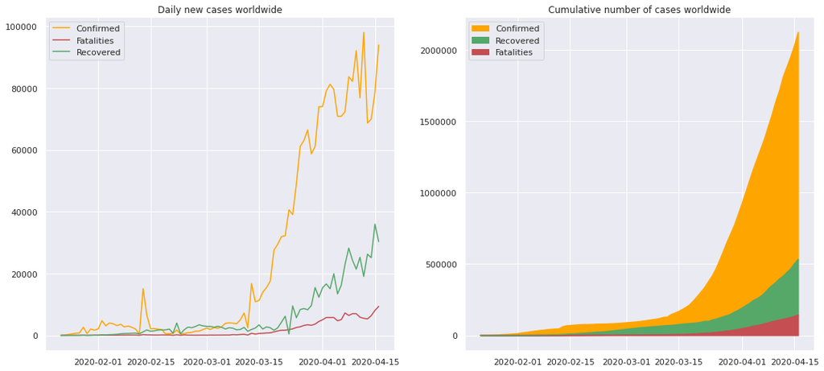

```python
by_date = df.groupby('date').sum()

def plot_total_and_daily(df):

  fig, ax = plt.subplots(1, 2, figsize=(18,8))

  ax[0].plot(df.daily_confirmed, label='Confirmed', color='orange')
  ax[0].plot(df.daily_fatalities, label='Fatalities', color='r')
  ax[0].plot(df.daily_recovered, label='Recovered', color='g')
  ax[0].legend()

  ax[1].plot(df.confirmed, color='orange')
  ax[1].plot(df.fatalities, color='r')
  ax[1].plot(df.recovered, color='g')
  ax[1].fill_between(df.index, df.confirmed, df.recovered, label='Confirmed', color='orange')
  ax[1].fill_between(df.index, df.recovered, df.fatalities, label='Recovered', color='g')
  ax[1].fill_between(df.index, df.fatalities, 0, label='Fatalities', color='r')
  ax[1].ticklabel_format(axis='y', style='plain')
  ax[1].legend()

  return fig, ax

fig, ax = plot_total_and_daily(by_date)
ax[0].set_title('Daily new cases worldwide')
ax[1].set_title('Cumulative number of cases worldwide')
plt.show()
```

**Observations:** The global curve shows a rich fine structure, but these numbers are strongly affected by the vector zero country, China. Given that COVID-19 started there, during the initial expansion of the virus there was no reliable information about the real infected cases. In fact, the criteria to consider infection cases was modified around 11th February 2020, which strongly perturbed the curve as we can see from the figure.

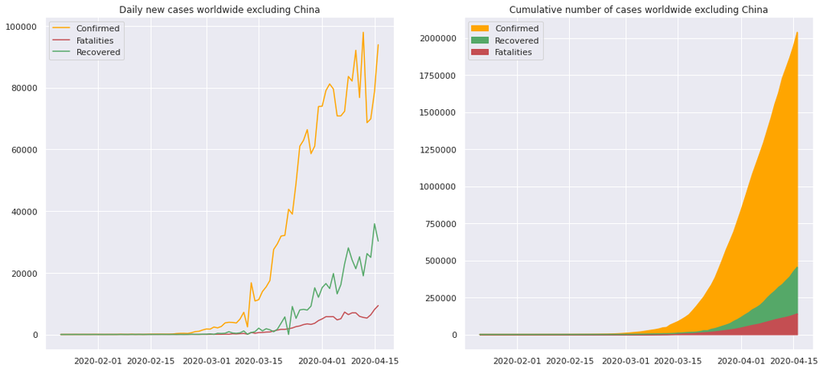

```python
by_date_no_china = df[df['country']!='China'].groupby('date').sum()

fig, ax = plot_total_and_daily(by_date_no_china)
ax[0].set_title('Daily new cases worldwide excluding China')
ax[1].set_title('Cumulative number of cases worldwide excluding China')
plt.show()
```

**Observations:** In this case the general behavior looks cleaner, and in fact the curve resembles a typical epidemiology model like **SIR**. SIR models present a large increasing in the number of infections that, once it reaches the maximum of the contagion, decreases with a lower slope.

#### 2. 1. 2. Confirmed, recovered and fatalities on a daily basis

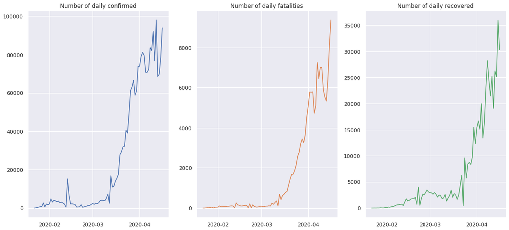

```python
PALETTE = itertools.cycle(sns.color_palette())

def plot_in_cols(df, to_plot=[]):

    n_plots = len(to_plot)

    fig, ax = plt.subplots(1, n_plots, figsize=(n_plots*6,8))

    for i, col in enumerate(to_plot):
        ax[i].plot(df[col], label=col.replace('_', ' '), color=next(PALETTE))
        ax[i].set_title('Number of ' + col.replace('_', ' '))
        ax[i].xaxis.set_major_locator(mdates.MonthLocator())
        ax[i].ticklabel_format(axis='y', style='plain')


    return fig, ax

fig, ax = plot_in_cols(by_date, to_plot=['daily_confirmed', 'daily_fatalities', 'daily_recovered'])
```

**Observations:** The following plots show a clear upward trend.

#### 2. 1. 3. Growth Factor

Growth factor is the factor by which a quantity multiplies itself over time. The formula used is every day's new cases / new cases on the previous day. For example, a quantity growing by 7% every period (in this case daily) has a growth factor of 1.07.

A growth factor above 1 indicates an increase, whereas one which remains between 0 and 1 it is a sign of decline, with the quantity eventually becoming zero, whereas a growth factor constantly above 1 could signal exponential growth

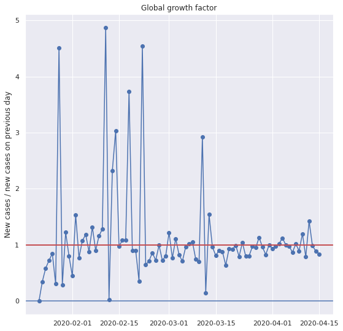

```python
def plot_growth_factor(df):

    fig, ax = plt.subplots(figsize=(9, 9))

    growth_factor = df['daily_confirmed'] / df['daily_confirmed'].shift(-1)

    ax.plot(df.index, growth_factor, marker='o')
    ax.axhline(0)
    ax.axhline(1, linewidth=2, color='r')
    ax.set_ylabel('New cases / new cases on previous day')

    return fig, ax

fig, ax = plot_growth_factor(by_date)
ax.set_title('Global growth factor')
plt.show()
```

#### 2. 1. 4. Active cases by date

By removing `fatalities` and `recovered` from total cases, we get "currently infected cases" or "**active cases**" (cases still awaiting for an outcome).

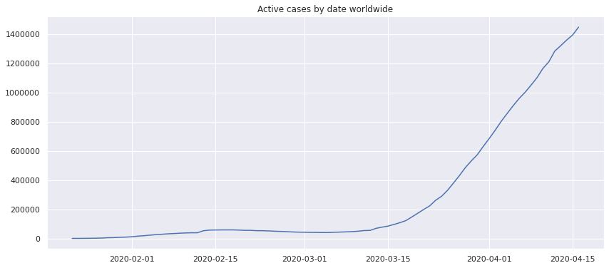

```python
def get_active_cases(df):
    active_cases = df['confirmed'] - df['recovered'] - df['fatalities']
    return active_cases

def plot_active_cases(df):

    fig, ax = plt.subplots(figsize=(14, 6))

    ax.plot(get_active_cases(df))
    ax.ticklabel_format(axis='y', style='plain')

    return fig, ax

fig, ax = plot_active_cases(by_date)
ax.set_title('Active cases by date worldwide')
plt.show()
```

**Observations**: It is important to know that not all recoveries are being accounted for.

#### 2. 1. 5. Top countries for total confirmed cases

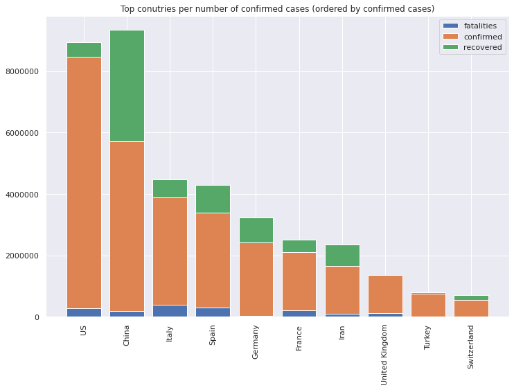

```python
by_country = merged.groupby('country').sum()

def plot_top_countries(df, n_countries=10):
    top = df.sort_values('confirmed', ascending=False).head(n_countries)

    fig, ax = plt.subplots(figsize=(12, 8))

    ax.bar(top.index, top['fatalities'], label='fatalities')
    ax.bar(top.index, top['confirmed'], bottom=top['fatalities'], label='confirmed')
    ax.bar(top.index, top['recovered'], bottom=top['confirmed'] + top['fatalities'], label='recovered')

    ax.set_xticklabels(top.index, rotation=90)
    ax.ticklabel_format(axis='y', style='plain')
    ax.legend()

    return fig, ax

fig, ax = plot_top_countries(by_country)
ax.set_title('Top conutries per number of confirmed cases (ordered by confirmed cases)')
plt.show()
```

**Observations:** Here we can see how the relationship between number of fatalities and recovered changes amongst the countries most afflicted by the coronavirus. In China more than half the people recovered and the number of fatalities has kept relatively low compared to US and other european countries. The same cannot be said for Italy and Spain, although these countries are still at a different stage of the pandemic.

#### 2. 1. 6. New cases for countries with most cases

Next I will be plotting the number of confirmed cases per country. I will not be using all countries for the following plots, the countries taken in consideration are the ones with the most number of cases.

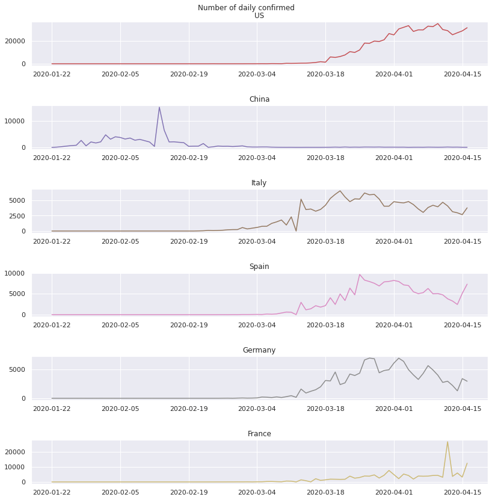

```python
def plot_subplots_for_country_cases(df, column, n_countries=5, **kwargs):

    top = df.groupby('country').sum().sort_values('confirmed', ascending=False).head(n_countries)

    fig, ax = plt.subplots(len(top), 1, **kwargs)

    for i, country in enumerate(top.index):
        country_df = df[df['country']==country]
        grouped_by_date = country_df.groupby('date')[column].sum()

        ax[i].plot(grouped_by_date, color=next(PALETTE))
        ax[i].set_title(country)
        ax[i].xaxis.set_ticks(grouped_by_date.index[::14])
        ax[i].ticklabel_format(axis='y', style='plain')

    fig.tight_layout(pad=3.0)

    fig.suptitle('Number of ' + column.replace('_', ' '))

    return fig, ax

fig, ax = plot_subplots_for_country_cases(df, n_countries=6, column='daily_confirmed', figsize=(12, 12))
```

**Observations:** We can see how China's curve is different compared to the other countries. Besides the fact that they were the first country to deal with the coronavirus outbreak the measures seem to have worked well as we can see a downwards trend in new cases after slightly more than one month.